# Genome-wide methylation analysis report

# Genome-wide methylation analysis report

- study: Pleural cfDNAm analysis of epithelioid_other_mesovariable
- author: Paul Yousefi
- date: 08 October, 2026

## Parameters

```
## $sig.threshold
## [1] 2.121143e-07
##
## $max.plots
## [1] 10
##
## $qq.inflation.method
## [1] "median"
##
## $practical.threshold
## [1] 6.507264e-05
```

## Sample characteristics

For continuous or ordinal variables, the “mean” column provides the mean and the “sd/%” column the standard deviation of the variable. For categorical variables, the “mean” column provides the number of samples with the given “value” and the “sd/%” column the percentage of samples with the given “value”.

| variable | value | mean | sd.. |
| --- | --- | --- | --- |
| epithelioid_other_meso |  | 0.7166667 | 0.4544196 |
| sv1 |  | -1.084202e-18 | 0.1301889 |
| sv2 |  | -9.459946e-19 | 0.1301889 |
| sv3 |  | -6.056215e-18 | 0.1301889 |
| sv4 |  | -1.309897e-17 | 0.1301889 |
| sv5 |  | 1.273938e-18 | 0.1301889 |
| sv6 |  | 1.820161e-17 | 0.1301889 |
| sv7 |  | 1.485357e-17 | 0.1301889 |
| sv8 |  | 1.423391e-14 | 0.1301889 |
| sv9 |  | 1.159028e-12 | 0.1301889 |
| sv10 |  | 1.036047e-12 | 0.1301889 |

## Covariate associations

### Covariate sv1

statistics

| var1 | var2 | F | p-value | R | p-value |
| --- | --- | --- | --- | --- | --- |
| epithelioid_other_meso | sv1 | 1.498448 | 0.2258596 | 0.0993102 | 0.4502845 |

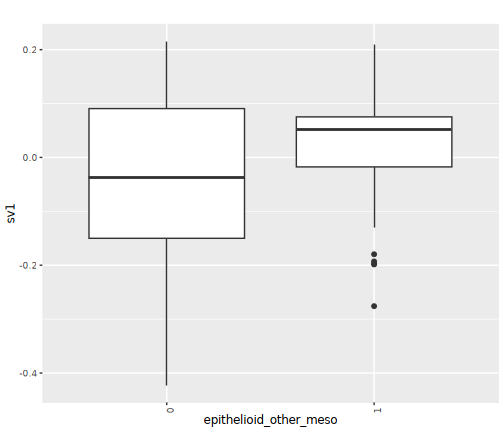

### Covariate sv2

statistics

| var1 | var2 | F | p-value | R | p-value |
| --- | --- | --- | --- | --- | --- |
| epithelioid_other_meso | sv2 | 0.1388008 | 0.710834 | 0.0331034 | 0.8017425 |

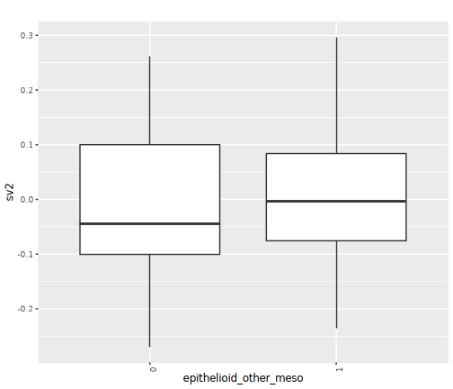

### Covariate sv3

statistics

| var1 | var2 | F | p-value | R | p-value |
| --- | --- | --- | --- | --- | --- |
| epithelioid_other_meso | sv3 | 0.6250482 | 0.4323984 | -0.0096107 | 0.941902 |

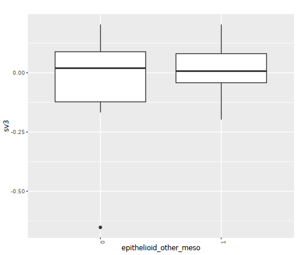

### Covariate sv4

statistics

| var1 | var2 | F | p-value | R | p-value |
| --- | --- | --- | --- | --- | --- |
| epithelioid_other_meso | sv4 | 0.0880285 | 0.7677585 | -0.028832 | 0.8269 |

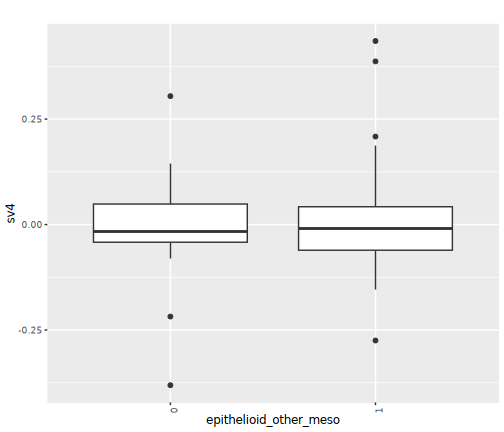

### Covariate sv5

statistics

| var1 | var2 | F | p-value | R | p-value |
| --- | --- | --- | --- | --- | --- |
| epithelioid_other_meso | sv5 | 0.9155809 | 0.3426095 | 0.0416462 | 0.752047 |

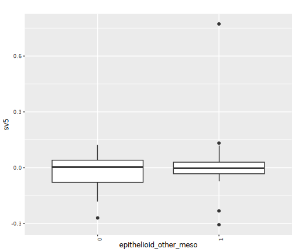

### Covariate sv6

statistics

[output not shown]

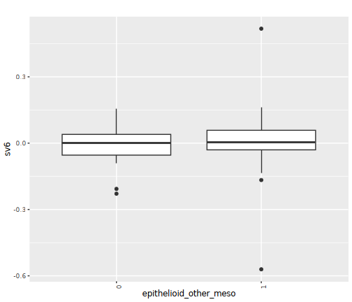

### Covariate sv7

statistics

| var1 | var2 | F | p-value | R | p-value |
| --- | --- | --- | --- | --- | --- |
| epithelioid_other_meso | sv7 | 1.21014 | 0.2758493 | 0.122803 | 0.3499109 |

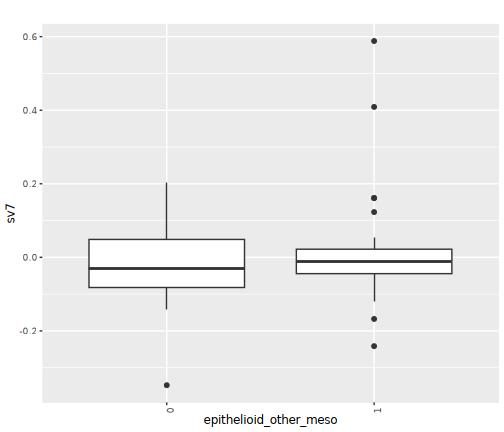

### Covariate sv8

statistics

[output not shown]

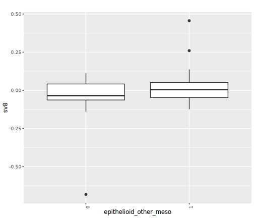

### Covariate sv9

statistics

| var1 | var2 | F | p-value | R | p-value |
| --- | --- | --- | --- | --- | --- |
| epithelioid_other_meso | sv9 | 0.1933327 | 0.6617913 | -0.1697884 | 0.1946485 |

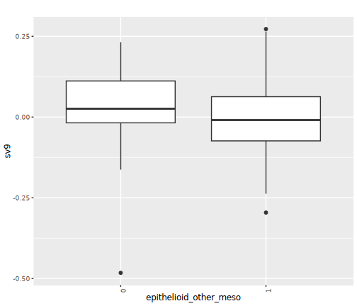

### Covariate sv10

statistics

| var1 | var2 | F | p-value | R | p-value |
| --- | --- | --- | --- | --- | --- |
| epithelioid_other_meso | sv10 | 1.117733 | 0.2947907 | -0.0971745 | 0.4601334 |

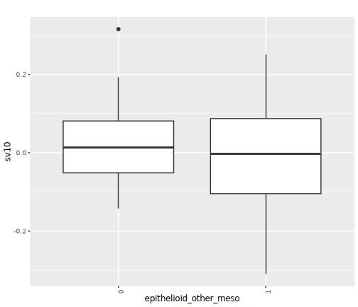

## QQ plots

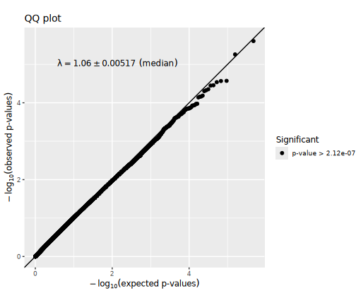

## Manhattan plots

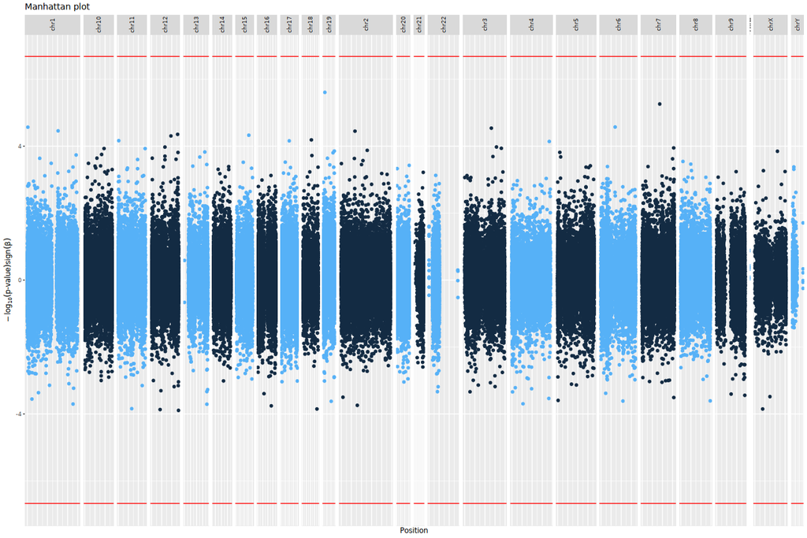

## Significant CpG sites

There were 0 CpG sites with association p-values < 2.1211427 × 10<sup>-7</sup>. These are listed in the file associations.csv.

Below are the 10 CpG sites with association p-values < 6.507264 × 10<sup>-5</sup> in the regression model.

|  | chromosome | position | estimate | p.value | p.adjust |
| --- | --- | --- | --- | --- | --- |
| cg19689672 | chr12 | 96001921 | 0.0549826 | 4.97e-05 | 1.0000000 |
| cg24082638 | chr19 | 9666638 | 0.0746518 | 2.50e-06 | 0.5835007 |
| cg20719592 | chr15 | 83746839 | 0.1246510 | 4.72e-05 | 1.0000000 |
| cg17882544 | chr1 | 2730824 | 0.0960405 | 2.71e-05 | 1.0000000 |
| cg11347156 | chr7 | 86684183 | 0.0851502 | 5.50e-06 | 1.0000000 |
| cg05530416 | chr3 | 131910723 | 0.0645109 | 2.90e-05 | 1.0000000 |
| cg18327664 | chr12 | 129169975 | 0.0953851 | 4.44e-05 | 1.0000000 |
| cg13371910 | chr6 | 69990372 | 0.1003666 | 2.69e-05 | 1.0000000 |
| cg13927088 | chr1 | 152691125 | 0.0819094 | 3.50e-05 | 1.0000000 |
| cg07784042 | chr2 | 67893948 | 0.1272966 | 3.57e-05 | 1.0000000 |

Plots of these sites follow, one for each covariate set. “p[lm]” denotes the p-value obtained using a linear model and “p[beta]” the p-value obtained using beta regression.

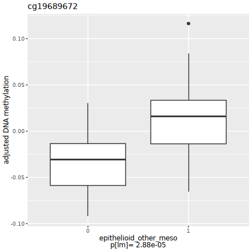

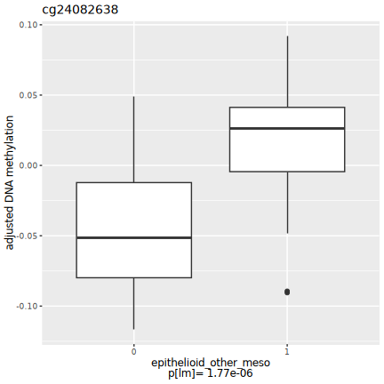

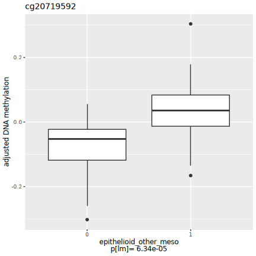

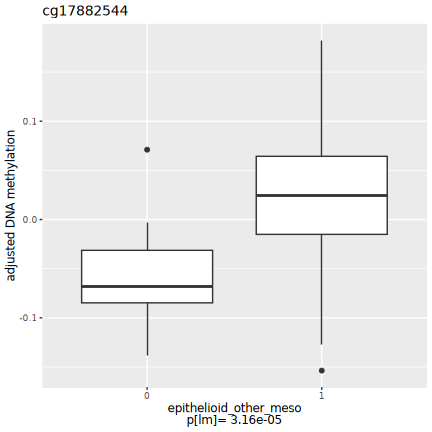

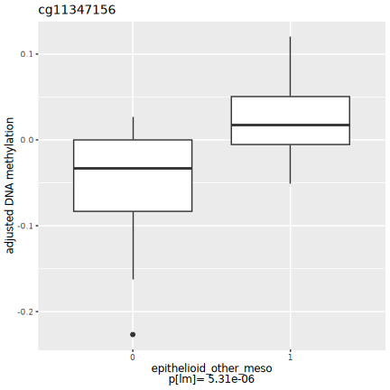

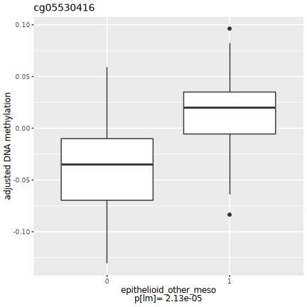

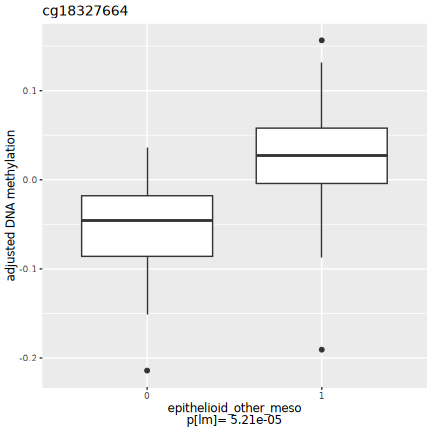

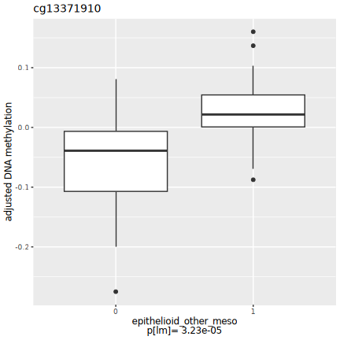

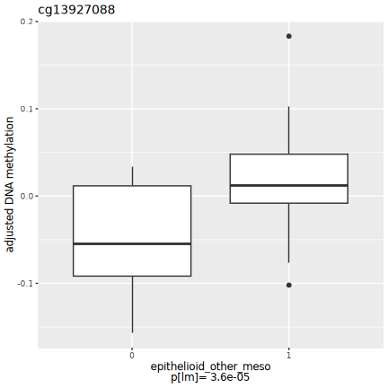

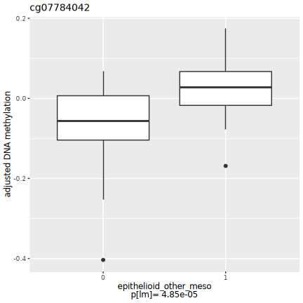

## Selected CpG sites

Number of CpG sites selected: 0.

| chromosome | position | estimate | p.value | p.adjust |
| --- | --- | --- | --- | --- |